# Introduction

This notebook presents the ongoing progress of a public health data science project focused on estimating Penta1 vaccination coverage and identifying zero-dose children. The broader goal is to leverage artificial intelligence to generate insights and support evidence-based decision-making for immunization strategies.

We aim to:

- Analyze vaccination data to estimate coverage and identify gaps.
- Quantify the number of children who remain unvaccinated.
- Explore how AI can enhance data interpretation and guide targeted interventions.

# Data Sources

This section outlines the datasets used in the analysis.

Most of the data related to Penta1 vaccination begins in 2021 within the DHIS2 system, which serves as the starting point for our analysis. Due to changes in national administrative boundaries over time, we initially present data at the Admin1 level for consistency. However, for integrated analysis, we use the smallest available administrative subdivisions to ensure granularity and accuracy.

## Penta 1 Vaccination & Penta 1 Coverage

The data for Penta 1 vaccination and Penta 1 coverage are extracted from the DHIS2.

### National Level

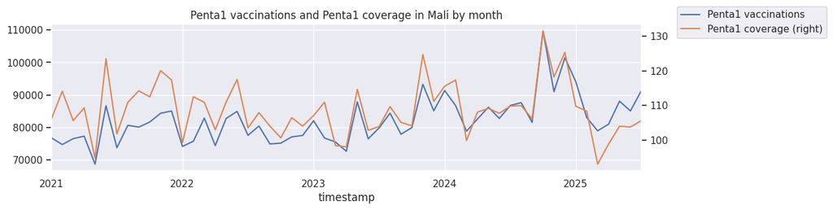

This analysis is AI generated from the data:

The provided dataset contains monthly data on Penta1 vaccinations and coverage in Mali, spanning from January 2021 to July 2025.

Overall Analysis of Penta1 Vaccinations and Coverage in Mali

The dataset provides a valuable insight into the Penta1 vaccination program in Mali. Here's a summary of the key statistics:

- **Time Period:** The data covers a period of 55 months, from January 2021 to July 2025.

- **Penta1 Vaccinations:**

  - The number of vaccinations ranges from a minimum of 68,758 to a maximum of 109,692.

  - The average number of vaccinations over the entire period is approximately 82,293.

  - There's a standard deviation of about 7,248, indicating some variability in monthly vaccination numbers.

- **Penta1 Coverage:**

  - Coverage rates vary from 93.04% to 131.50%.

  - The average coverage is around 108.78%.

  - The standard deviation of 7.74 suggests moderate fluctuations in coverage.

It's important to note that coverage rates exceeding 100% can occur due to various factors, such as population estimates being lower than the actual target population, or inclusion of children vaccinated outside their birth cohort.

Evolution Over Time and Trends

To understand the evolution and trends, let's look at the yearly average for both vaccinations and coverage:

| Year | Average Penta1 Vaccinations | Average Penta1 Coverage |
| --- | --- | --- |
| 2021 | 78,908.92 | 110.83% |
| 2022 | 78,181.08 | 106.72% |
| 2023 | 81,029.17 | 107.54% |
| 2024 | 88,908.00 | 113.21% |
| 2025 | 85,971.71 | 103.33% |

**Observations:**

- **Vaccinations:**

  - There was a slight dip in average vaccinations from 2021 to 2022.

  - A positive trend is observed from 2022 to 2024, with a significant increase in average vaccinations.

  - The data for 2025 (up to July) shows a slight decrease compared to 2024, but it's still higher than 2021-2023 averages.

- **Coverage:**

  - Coverage also saw a decrease from 2021 to 2022.

  - Similar to vaccinations, coverage generally increased from 2022 to 2024.

  - The 2025 data (up to July) indicates a noticeable drop in average coverage compared to previous years.

Overall, there appears to be a general upward trend in Penta1 vaccinations and coverage from 2022 to 2024, suggesting improvements in the vaccination program during this period. However, the initial data for 2025 indicates a potential decline that warrants further investigation.

Focus on the Last Year (2024)

The last full year of data available is 2024. Let's examine the performance during this period in more detail:

- **Penta1 Vaccinations in 2024:**

  - The average number of vaccinations in 2024 was approximately 88,908, which is the highest annual average in the dataset.

  - Monthly vaccinations ranged from 78,889 to 109,692.

  - This indicates a strong performance in terms of vaccination delivery throughout 2024.

- **Penta1 Coverage in 2024:**

  - The average coverage rate in 2024 was approximately 113.21%, also the highest annual average.

  - Monthly coverage varied from 99.85% to 131.50%.

  - The consistently high coverage rates in 2024 suggest effective outreach and vaccination efforts.

**Comparison with 2025 (Partial Data):**

While 2024 showed excellent performance, the partial data for 2025 (January to July) presents a different picture:

- **Penta1 Vaccinations in 2025 (partial):** The average vaccinations dropped to approximately 85,971, a decrease from 2024.

- **Penta1 Coverage in 2025 (partial):** The average coverage significantly decreased to approximately 103.33%, which is the lowest annual average in the dataset.

This suggests a potential decline in vaccination efforts or challenges in reaching the target population in the first half of 2025. It would be crucial to analyze the reasons behind this drop to ensure the continued success of the Penta1 vaccination program in Mali.

### Admin1 Level

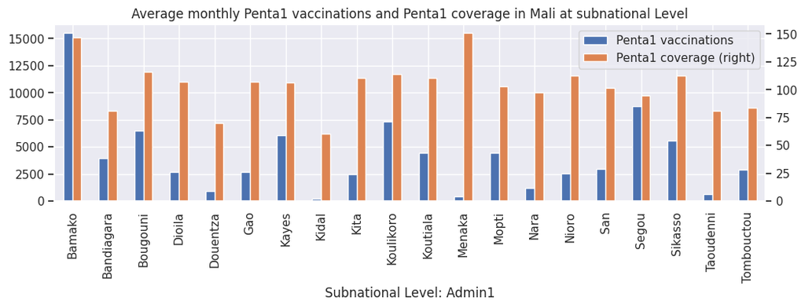

This analysis is AI generated from the data:

Here's a summary of the Penta1 vaccination data in Mali:

Data Overview

The dataset contains 1099 entries with information on Penta1 vaccination and coverage across different regions in Mali, spanning from January 2021 to July 2025.

- **Columns:**

  - `timestamp`: Date and time of the record (datetime64[ns])

  - `displayName`: Name of the region (object)

  - `penta1_vaccination`: Number of Penta1 vaccinations (float64)

  - `penta1_coverage`: Percentage of Penta1 coverage (float64)

Descriptive Statistics

| Statistic | Penta1 Vaccination | Penta1 Coverage |
| --- | --- | --- |
| **Count** | 1099 | 1099 |
| **Mean** | 4118.41 | 103.34 |
| **Standard Deviation** | 3564.51 | 27.76 |
| **Minimum** | 11.00 | 3.02 |
| **25th Percentile** | 1806.50 | 88.58 |
| **50th Percentile** | 3011.00 | 104.67 |
| **75th Percentile** | 5683.50 | 116.89 |
| **Maximum** | 18558.00 | 243.96 |

Regions Covered

The dataset includes data for the following 20 regions: Bamako, Bandiagara, Bougouni, Dioila, Douentza, Gao, Kayes, Kidal, Kita, Koulikoro, Koutiala, Menaka, Mopti, Nara, San, Sikasso, Segou, Taoudenni, Tombouctou, Nioro.

Region to Focus On

Based on the most recent data (July 2025), the government should focus on **Kidal**, as it has the lowest Penta1 coverage at **3.02%**.

## Conflict and Fatalities

These data are extracted from https://data.humdata.org/dataset/mali-acled-conflict-data

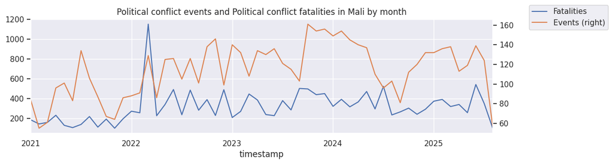

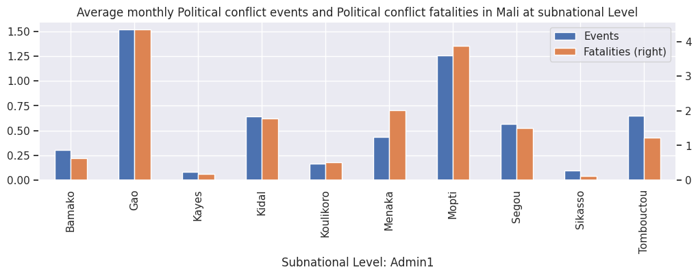

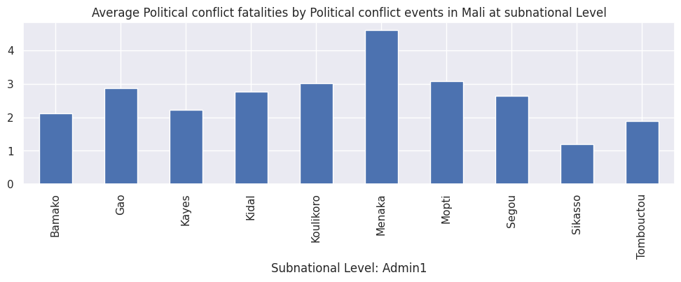

## Penta Closing Stock

This data is extracted from the DHIS2. It represents the available stock of Penta at the end of the month.

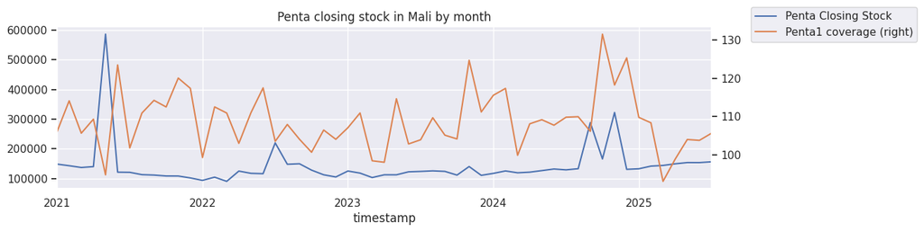

## Corrected Penta1 Coverage

This data will be updated as we progress towards an efficient method of estimation of the Penta1 coverage and Penta1 vaccinations.

For now, as a first step, we proposed a first methode of correction: carrying over the unvaccinated population of the previous months.  
The hypothesis is that unvaccinated children from the precedent month do not vanish and are still unvaccinated during the next month.

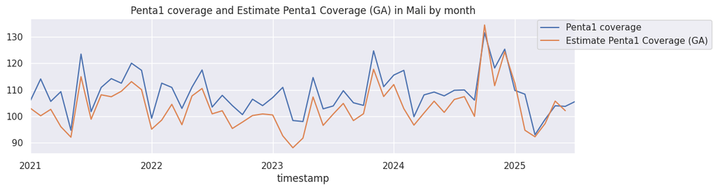

# Exploratory Data Analysis

We will focus on the penta1 vaccinations and the potential covariates.

## Number of vaccination

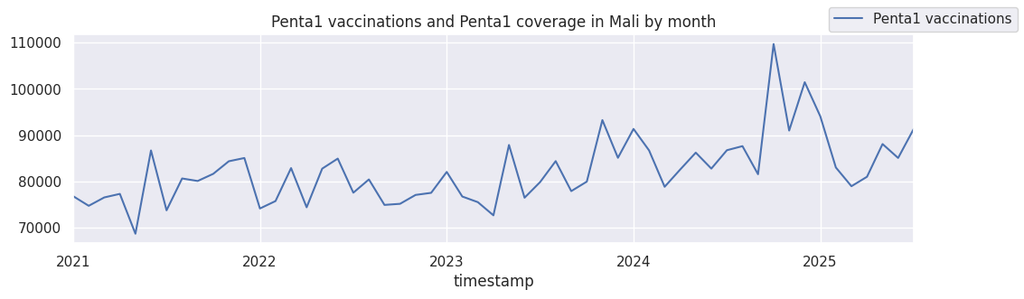

### Number of vaccination depending of past value

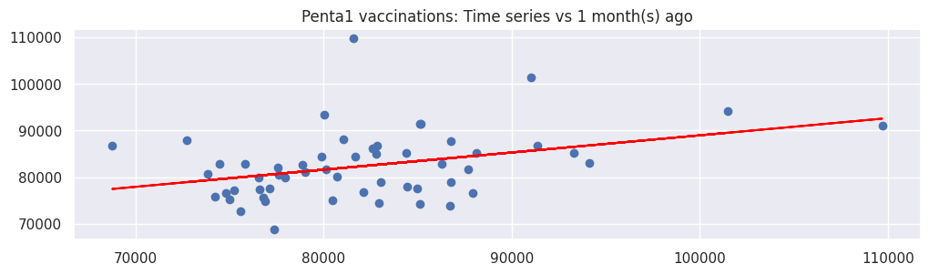

# Trends

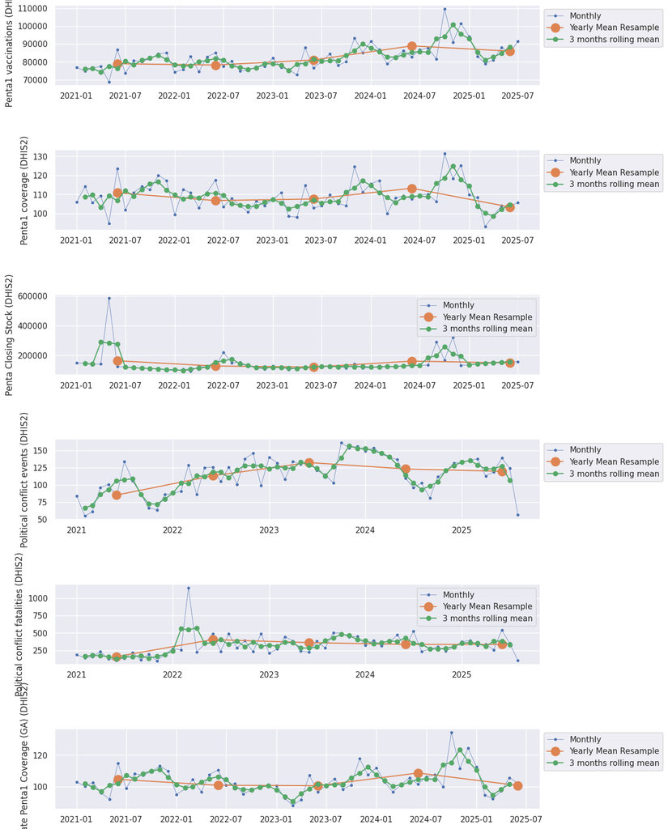

# Data Analysis

## Relation between variables

```
Correlation between Penta1 vaccinations and stock at n-1: 0.1928597106168343
```

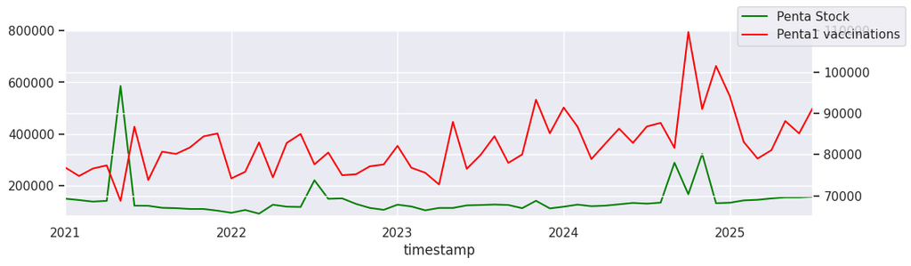

### Correlation between the number of vaccinations and number of Political Violence Events

```
Correlation between Penta1 vaccinations and number of Events (conflict): 0.24511468792244107
```

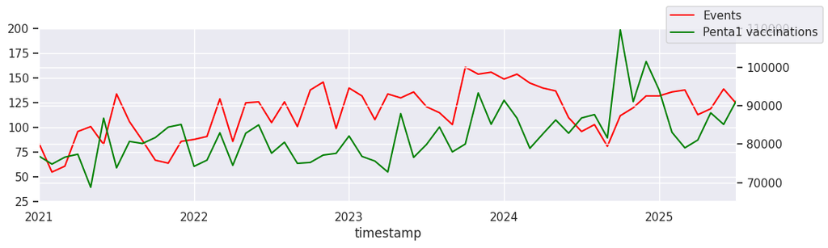

There is a really weak link between the number of Events and the number of vaccination.  
By looking at the graph, it seems that sometimes, the number of Events and the number of vaccinations are linked.  
This could be due of the difference in where the events happen or something similar.  
We will take a look at the correlation between Penta1 vaccinations and number of Events in each admin1.

```
Correlation between Penta1 vaccinations and number of Events or Fatalities (conflict) at n-1 in each admin1:
Kidal: (Events):-0.6022156353669266 / (Fatalities):-0.38556238574406193
Menaka: (Events):0.06336233712293521 / (Fatalities):0.14706702807487387
Tombouctou: (Events):-0.17113778472247027 / (Fatalities):-0.24510160056823313
Bamako: (Events):0.08176357526624013 / (Fatalities):0.276399767307727
Mopti: (Events):-0.16625383705793753 / (Fatalities):-0.03420032263381789
Kayes: (Events):-0.039679955647568786 / (Fatalities):0.06341408788209422
Segou: (Events):0.005057895928635772 / (Fatalities):-0.034570111588935394
Koulikoro: (Events):0.3499962650123863 / (Fatalities):0.14630789656802362
Sikasso: (Events):0.13598048031675763 / (Fatalities):0.08326288346620331
Gao: (Events):0.0569304731103532 / (Fatalities):-0.06936416822195399
```

When we considered the number of Events from the whole country, the correlation was around 0.24 (out of 1). When we look at the correlation between Penta1 vaccinations and number of Events in each admin1, we can see that there is a correlation between the two variables in Kidal.

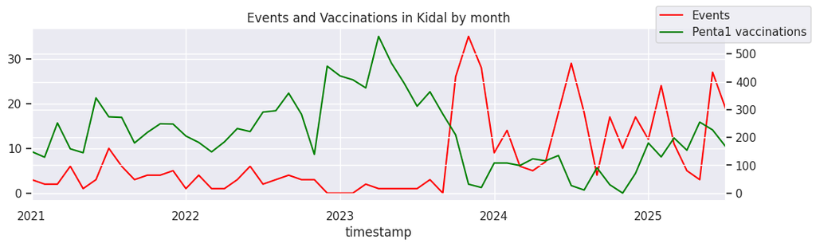

# Forecasting

The goal is to predict the number of Penta1 vaccinations in the future.  
We will explore two strategies: a prediction at a national level and a prediction at a subnational level.

## National level

To simulate a real life scenario, we will split the data into a train and a test set.

We will make prediction using data from 2021 to 2023, and we will be using data from 2023 to 2024 to optimize the prediction.  
Finally, we will evaluate the final models using the data from 2024 to 2025.

```
Training dates   : 2021-01-01 00:00:00 --- 2023-01-01 00:00:00  (n=25)
Validation dates : 2023-01-01 00:00:00 --- 2024-01-01 00:00:00  (n=13)
Test dates       : 2024-01-01 00:00:00 --- 2025-07-01 00:00:00  (n=19)
```

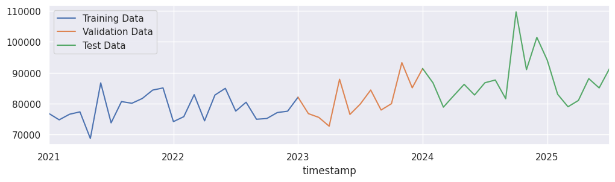

### Seasonality

Seasonal plots are a useful tool for identifying seasonal patterns and trends in a time series.

We will check for a monthly seasonality in the data.

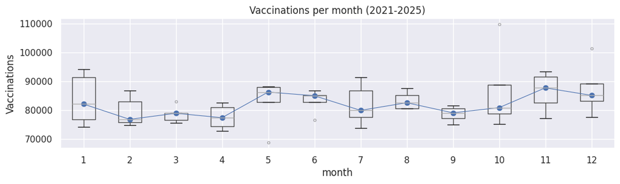

Number of vaccination seems to have low fluctuation in March, June, and September.  
Number of vaccination seems to have high fluctuation in January, July, October and November.  
Highest number of vaccination is in October, lowest number of vaccination is in Mai.

It seems there is monthly seasonality in the data: the peak number of vaccination is between Mai and June and between November and December.  
Lowest number of vaccination will be between February and April.

### Autocorrelation

Autocorrelation is a measure of the correlation between a time series and its own lagged values.

In simple terms, it measures the relation between the current value and the value in the past.

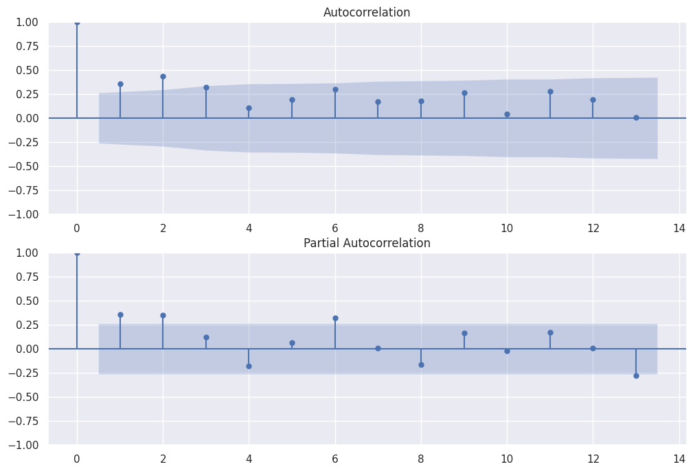

|  | lag | partial_autocorrelation_abs | partial_autocorrelation | autocorrelation_abs | autocorrelation |
| --- | --- | --- | --- | --- | --- |
| 0 | 13 | 0.425546 | -0.425546 | 0.006710 | 0.006710 |
| 1 | 6 | 0.374650 | 0.374650 | 0.299305 | 0.299305 |
| 2 | 2 | 0.366409 | 0.366409 | 0.433579 | 0.433579 |
| 3 | 1 | 0.363096 | 0.363096 | 0.356494 | 0.356494 |
| 4 | 11 | 0.225790 | 0.225790 | 0.275877 | 0.275877 |
| 5 | 8 | 0.215959 | -0.215959 | 0.175602 | 0.175602 |
| 6 | 9 | 0.212395 | 0.212395 | 0.261691 | 0.261691 |
| 7 | 4 | 0.192897 | -0.192897 | 0.109148 | 0.109148 |
| 8 | 3 | 0.132107 | 0.132107 | 0.317526 | 0.317526 |
| 9 | 5 | 0.066606 | 0.066606 | 0.192294 | 0.192294 |

### Baseline model

We will use a simple model to predict the number of vaccination in the future.  
This will be a baseline model and will be use to evaluate if more complex models are better.

We will use a Seasonal Naive Forecasting model, which is simply returning the value observed in the same period of the previous season (in our case, the same month, but in the previous year).

```
Information of folds
--------------------
Number of observations used for initial training: 24
Number of observations used for backtesting: 31
    Number of folds: 3
    Number skipped folds: 0
    Number of steps per fold: 12
    Number of steps to exclude between last observed data (last window) and predictions (gap): 0
    Last fold only includes 7 observations.

Fold: 0
    Training:   2021-01-01 00:00:00 -- 2022-12-01 00:00:00  (n=24)
    Validation: 2023-01-01 00:00:00 -- 2023-12-01 00:00:00  (n=12)
Fold: 1
    Training:   No training in this fold
    Validation: 2024-01-01 00:00:00 -- 2024-12-01 00:00:00  (n=12)
Fold: 2
    Training:   No training in this fold
    Validation: 2025-01-01 00:00:00 -- 2025-07-01 00:00:00  (n=7)
```

```
Absolute Mean error: 6079.129032258064
```

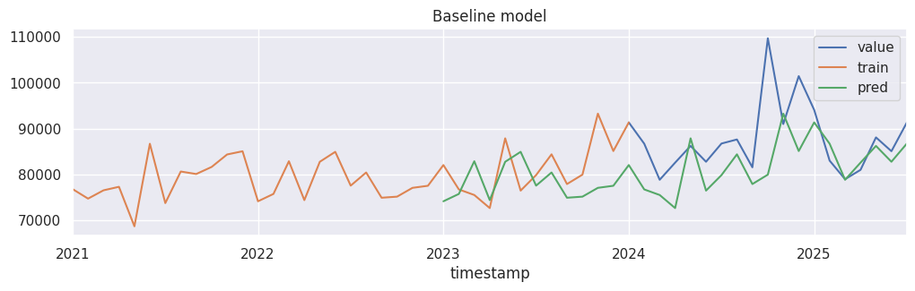

The model has an average error around 6000 vaccinations per months by just using the same value of the previous year.

### Autoregressive model

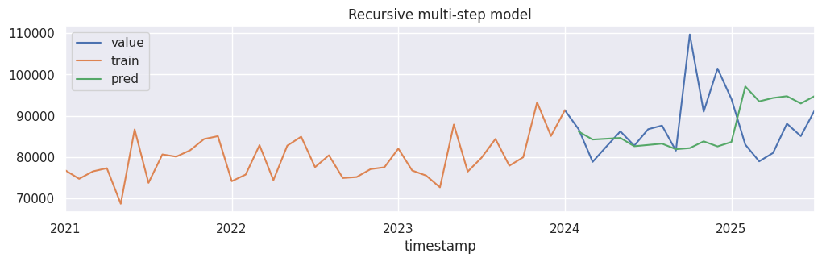